# QC_clustering_DEA

Charles

2022-07-28

## Description

This is a public data set with accession number [GSE178318](https://www.ncbi.nlm.nih.gov/geo/query/acc.cgi). It consists of a Single-Cell Atlas of Liver Metastases of Colorectal Cancer to Reveal the Reprogramming of the Tumor Microenvironment in Response to Preoperative Chemotherapy.

The goals will change progressively, but for now, one of the principal goals is to check the expression of lymphotoxins in metastasised liver cancer cells from CRC.

## Loading libraries

```r
library(Seurat)
library(SeuratObject)
library(SeuratWrappers)
library(SeuratDisk)
library(ggplot2)
library(tidyverse)
library(openxlsx)
library(Matrix)
```

## **1. Preparation for quality control**

### **1. Load in the raw data, prepare it and create the seurat object**

```r
# check files
list.files("rawData")
```

```
## [1] "cell_filtered_seurat.rds" "GSE178318_barcodes.tsv"
## [3] "GSE178318_genes.tsv"      "GSE178318_matrix.mtx"
```

```r
barcodes <- read.table("rawData/GSE178318_barcodes.tsv", header = FALSE, sep = "\t")
head(barcodes)
```

```
##                           V1
## 1 AAACCTGAGAAACCTA_COL07_CRC
## 2 AAACCTGAGACAATAC_COL07_CRC
## 3 AAACCTGAGACGCAAC_COL07_CRC
## 4 AAACCTGAGCAGATCG_COL07_CRC
## 5 AAACCTGAGCTATGCT_COL07_CRC
## 6 AAACCTGAGGACATTA_COL07_CRC
```

```r
genes <- read.table("rawData/GSE178318_genes.tsv", header = FALSE, sep = "\t")
head(genes)
```

```
##                V1            V2
## 1 ENSG00000243485  RP11-34P13.3
## 2 ENSG00000237613       FAM138A
## 3 ENSG00000186092         OR4F5
## 4 ENSG00000238009  RP11-34P13.7
## 5 ENSG00000239945  RP11-34P13.8
## 6 ENSG00000239906 RP11-34P13.14
```

```r
raw_matrix <- readMM("rawData/GSE178318_matrix.mtx")
dim(raw_matrix)
```

```
## [1]  33694 140281
```

```r
# set row names and column names
rownames(raw_matrix) <- genes$V2
colnames(raw_matrix) <- barcodes$V1

# verify row names and column names
rownames(raw_matrix)[1:10]
```

```
##  [1] "RP11-34P13.3"  "FAM138A"       "OR4F5"         "RP11-34P13.7"
##  [5] "RP11-34P13.8"  "RP11-34P13.14" "RP11-34P13.9"  "FO538757.3"
##  [9] "FO538757.2"    "AP006222.2"
```

```r
colnames(raw_matrix)[1:10]
```

```
##  [1] "AAACCTGAGAAACCTA_COL07_CRC" "AAACCTGAGACAATAC_COL07_CRC"
##  [3] "AAACCTGAGACGCAAC_COL07_CRC" "AAACCTGAGCAGATCG_COL07_CRC"
##  [5] "AAACCTGAGCTATGCT_COL07_CRC" "AAACCTGAGGACATTA_COL07_CRC"
##  [7] "AAACCTGAGGATGGTC_COL07_CRC" "AAACCTGAGGATTCGG_COL07_CRC"
##  [9] "AAACCTGAGGCTAGCA_COL07_CRC" "AAACCTGAGGCTCAGA_COL07_CRC"
```

```r
# save back the matrix
saveRDS(raw_matrix,
        "objects/raw_matrix.rds", compress = FALSE)

# to create seurat object
seurat <- CreateSeuratObject(raw_matrix,
                             min.cells = 10,
                             names.delim = "_")
rm(raw_matrix)
gc()
```

```
##             used   (Mb) gc trigger   (Mb)   max used   (Mb)
## Ncells   3835786  204.9    7498101  400.5    7498101  400.5
## Vcells 257855591 1967.3  968810018 7391.5 1100002416 8392.4
```

The data set has been loaded, gene names and column names added. But looking at the column names, it appears that the last item after the last underscore is specifying if the tissue origin of the cell, i.e. if it is CRC or not. So using string separation, I will evaluate all additional information that might be hidden in the barcode string.

### **2. Add cell tissue origin to the seurat object’s metadata**.

```r
barcodes <- barcodes %>%
                      separate(V1, into = c("barcode", "subjectID", "tissue_origin"), sep = "_")
seurat$subjectID <- barcodes$subjectID
seurat$group <- barcodes$tissue_origin

# save the raw seurat object
saveRDS(seurat,
        "objects/raw_seurat.rds", compress = FALSE)

table(seurat$group)
```

```
##
##   CRC    LM  PBMC
## 55735 57596 26950
```

**CRC** are the colorectal carcinoma primary tissue, **LM** are the liver metastasis tissue **PBMC** are the Peripheral blood mononuclear cells

Data set has been read in, prepared and seurat object sucessfully created and raw seurat object saved.

## **Perform quality control**

## **Calculate percentages of genes in each cell that map tp mitochondrial or ribosomal genes.**

```r
# Compute percent ribo and mito ratios
seurat$riboRatio <- PercentageFeatureSet(object = seurat, pattern = "^RP[SL]")
seurat$riboRatio <- seurat@meta.data$riboRatio / 100

# check success of calculation
summary(seurat$riboRatio)
```

```
##     Min.  1st Qu.   Median     Mean  3rd Qu.     Max.
## 0.004246 0.219537 0.289080 0.293772 0.363848 0.832714
```

```r
seurat$mitoRatio <- PercentageFeatureSet(object = seurat, pattern = "^MT")
seurat$mitoRatio <- seurat@meta.data$mitoRatio / 100

# check success of calculation
summary(seurat$mitoRatio)
```

```
##    Min. 1st Qu.  Median    Mean 3rd Qu.    Max.
## 0.00000 0.02303 0.03163 0.05872 0.04466 0.98624
```

```r
# create path to the directories
figuresdir <- paste0("figures/")
figuresdir
```

```
## [1] "figures/"
```

```r
objectsdir <- paste0("objects/")
objectsdir
```

```
## [1] "objects/"
```

```r
resultsdir <- paste0("results/")
resultsdir
```

```
## [1] "results/"
```

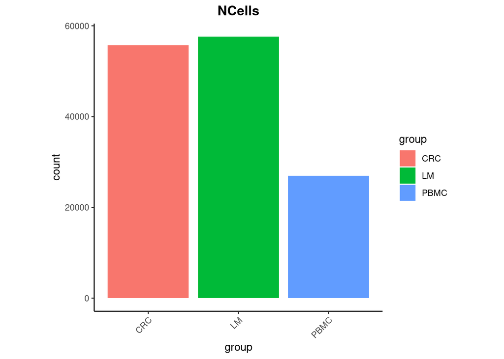

```r
# Visualize the number of cell counts per sample
seurat@meta.data %>%
        ggplot(aes(x=group, fill=group)) +
        geom_bar() +
        theme_classic() +
        theme(axis.text.x = element_text(angle = 45, vjust = 1, hjust=1),
              aspect.ratio = 1) +
        theme(plot.title = element_text(hjust=0.5, face="bold")) +
        ggtitle("NCells")
```

```r
ggsave(filename=paste0(figuresdir, "/", "cell_counts_per_sample",
                       ".png"), width = 5,
       height = 5, units = 'in', dpi = 300)
```

### **Calculate the number of UMI counts per cell in each group - with histogram.**

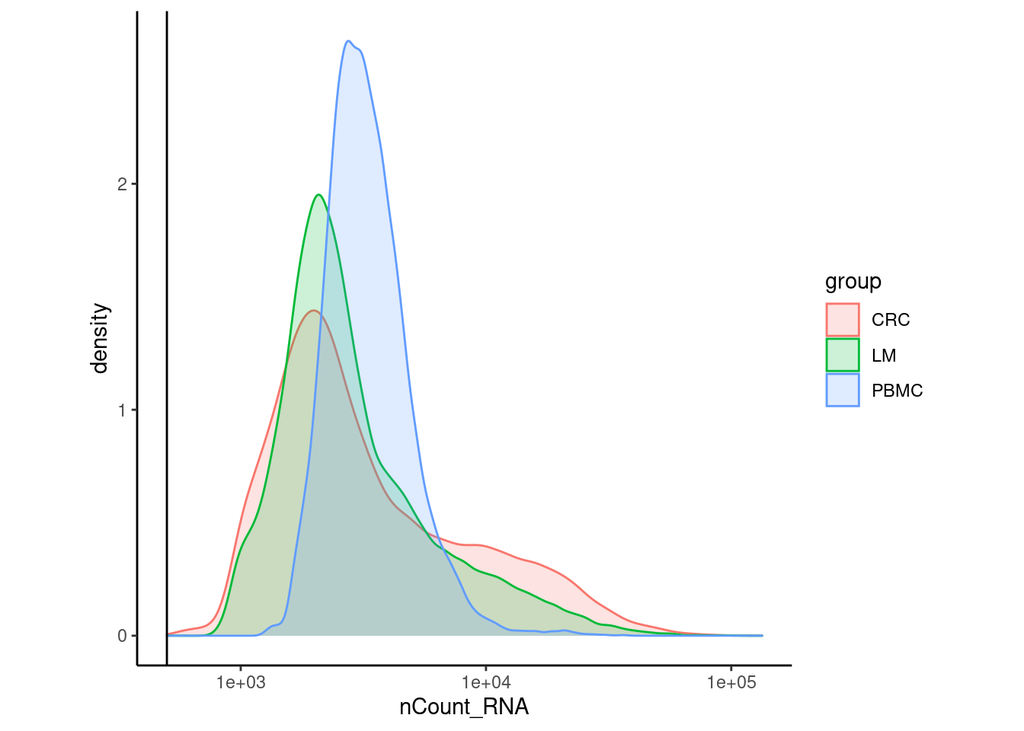

```r
# Visualize the distribution of transcripts detected per cell via a histogram
seurat@meta.data %>%
        ggplot(aes(color=group, x=nCount_RNA, fill= group)) +
        geom_density(alpha = 0.2) +
        theme_classic() +
        scale_x_log10() +
        geom_vline(xintercept = 500) +
      theme(aspect.ratio = 1)
```

```r
ggsave(filename=paste0(figuresdir, "/", "genes_per_cell_final",
                       ".png"), width = 5,
       height = 5, units = 'in', dpi = 300)
```

Most of the UMI counts are between 500 and 100000, with a peak at 3000. The UMI counts per cell should generally be above 500, that is the low end of what we expect.

### **Calculate the number of of UMI counts per cell in each group - boxplot.**

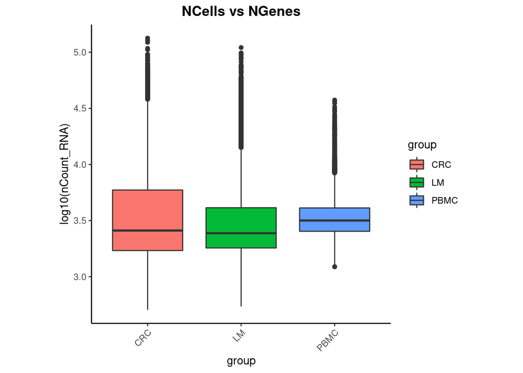

```r
# Visualize the distribution of genes detected per cell via boxplot
seurat@meta.data %>%
        ggplot(aes(x=group, y=log10(nCount_RNA), fill=group)) +
        geom_boxplot() +
        theme_classic() +
        theme(axis.text.x = element_text(angle = 45, vjust = 1, hjust=1),
              aspect.ratio = 1) +
        theme(plot.title = element_text(hjust=0.5, face="bold")) +
        ggtitle("NCells vs NGenes")
```

```r
ggsave(filename=paste0(figuresdir, "/", "boxplot_genes_per_cell_final",
                       ".png"), width = 5,
       height = 5, units = 'in', dpi = 300)
```

The results from the box plot above shows that more transcripts are detected in the PBMC group compared to the rest. This could mean a higher sequencing depth in favour of PBMCs. This will be handled during normalisation.

### **Calculate the number of genes detected per cell in each group.**

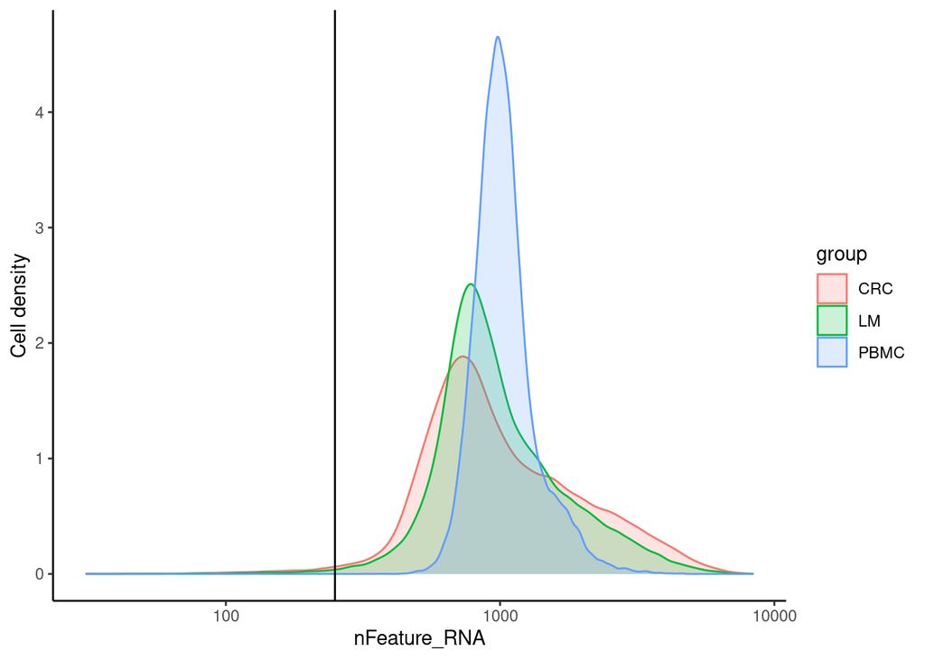

```r
seurat@meta.data %>%
        ggplot(aes(color=group, x=nFeature_RNA, fill= group)) +
        geom_density(alpha = 0.2) +
        scale_x_log10() +
        theme_classic() +
        ylab("Cell density") +
        geom_vline(xintercept = 250)
```

```r
ggsave(filename=paste0(figuresdir, "/", "UMI_per_cell_final",
                       ".png"), width = 5,
       height = 5, units = 'in', dpi = 300)
```

We can see that most of the cells have between 800 and 1000 genes detected. It is however worth noticing that that the number of genes detected per cell is higher in the PBMCs compared to LM and CRC conditions.

### **Calculate relation between number of genes, number of transcripts and mitochondrial ratio per cell and group.**

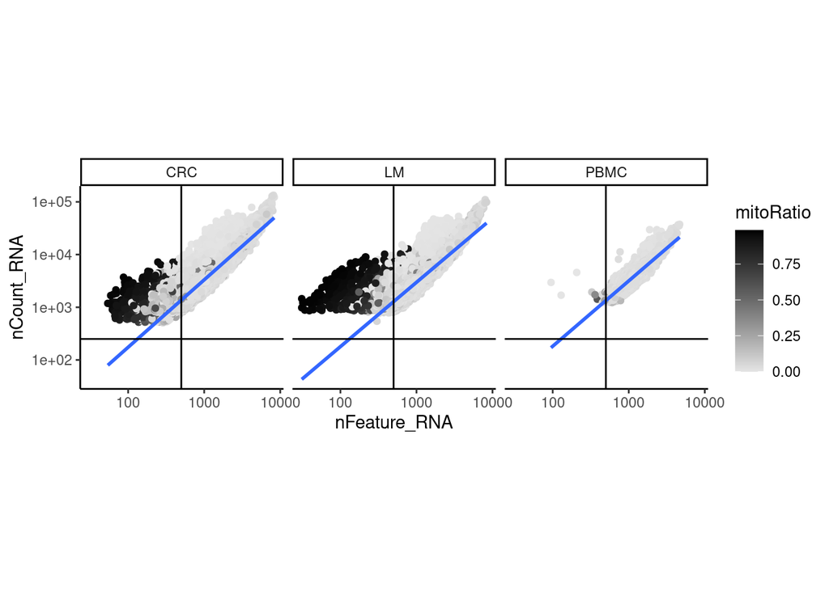

```r
seurat@meta.data %>%
        ggplot(aes(x=nFeature_RNA, y=nCount_RNA, color=mitoRatio)) +
        geom_point() +
    scale_colour_gradient(low = "gray90", high = "black") +
        stat_smooth(method=lm) +
        scale_x_log10() +
        scale_y_log10() +
        theme_classic() +
        geom_vline(xintercept = 500) +
        geom_hline(yintercept = 250) +
        facet_wrap(~group) +
      theme(aspect.ratio = 1)
```

```r
ggsave(filename=paste0(figuresdir, "/", "mitoratio_genes_and_UMI_final",
                       ".png"), width = 5,
       height = 5, units = 'in', dpi = 300)
```

When we look at the four quadrants of each group, wee see that the upper left quadrant of the cells from the CRC and LM samples, have cells that have a high amount of transcripts but a low number of genes detected. They also have very high percentages of their genes being of mitochondrial origin. This might reflect dead or dying cells. But we also see that the cells have high nUMI counts, so do not meet the criteria of dying cells, that usually have low transcript numbers. It might also be a cell type, that have high use of mitochondrial activity and have very few active genes that code for a large number of transcripts. The phenomenon described above is visibly is absent in the PBMC sample. These inconclusive observations will be kept in mind during subsequent analyses.

### **Visualise the mitochondrial counts ratio.**

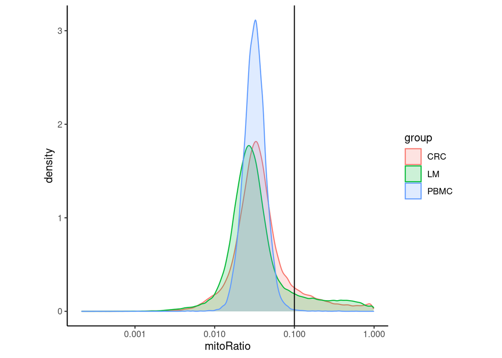

The results show a unimodal distribution of mitochondrial ratios per cell within each group. Intuitively this should reflect reduced number of dead cells. If we had a large number of dead cells, we would have a bimodal distribution of mitochondrial ratio counts. I will select all cells with mitoRatio < 0.1.

### Calculate and visualise complexity.

This metric is to assess the ratio of the number of genes to transcripts. it gives an idea about complexity. Do we have a few very active genes that code for a high number of transcripts? If it is the case, are the less complex cell such as RBCs or may be some cell type that suffered from faulty sequencing or library preparation process.

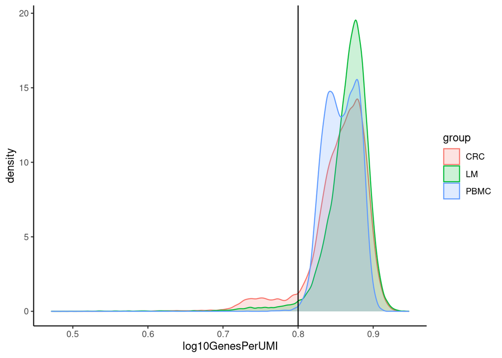

```r
# Add number of genes per UMI for each cell to metadata
seurat$log10GenesPerUMI <- log10(seurat$nFeature_RNA) / log10(seurat$nCount_RNA)

# Visualize the overall complexity of the gene expression by visualizing the genes detected per UMI
seurat@meta.data %>%
        ggplot(aes(x=log10GenesPerUMI, color = group, fill=group)) +
        geom_density(alpha = 0.2) +
        theme_classic() +
        geom_vline(xintercept = 0.8)
```

```r
ggsave(filename=paste0(figuresdir, "/", "complexity_of_gene_expression_final",
                       ".png"), width = 5,
       height = 5, units = 'in', dpi = 300)
```

Most of the cells are highly complex, i.e. complexity score greater than 0.8. All samples practically have their peak in the same location.

### **Cell filtering to remove low quality cells.**

```r
# inspect metadata
head(seurat@meta.data)
```

```
##                               orig.ident nCount_RNA nFeature_RNA subjectID
## AAACCTGAGAAACCTA_COL07_CRC SeuratProject       5565         1241     COL07
## AAACCTGAGACAATAC_COL07_CRC SeuratProject       5892         1845     COL07
## AAACCTGAGACGCAAC_COL07_CRC SeuratProject       3371          932     COL07
## AAACCTGAGCAGATCG_COL07_CRC SeuratProject        945          548     COL07
## AAACCTGAGCTATGCT_COL07_CRC SeuratProject       1565          571     COL07
## AAACCTGAGGACATTA_COL07_CRC SeuratProject       1865          816     COL07
##                            group riboRatio   mitoRatio log10GenesPerUMI
## AAACCTGAGAAACCTA_COL07_CRC   CRC 0.5399820 0.006469003        0.8260047
## AAACCTGAGACAATAC_COL07_CRC   CRC 0.2673116 0.016802444        0.8662517
## AAACCTGAGACGCAAC_COL07_CRC   CRC 0.4574310 0.029071492        0.8417287
## AAACCTGAGCAGATCG_COL07_CRC   CRC 0.2021164 0.027513228        0.9204649
## AAACCTGAGCTATGCT_COL07_CRC   CRC 0.1559105 0.401277955        0.8629281
## AAACCTGAGGACATTA_COL07_CRC   CRC 0.2643432 0.035388740        0.8902403
```

```r
# Filter out low quality reads using selected thresholds - these will change with experiment
filtered_seurat <- subset(x = seurat,
                         subset= (nCount_RNA >= 500) &
                           (nFeature_RNA >= 250) &
                           (log10GenesPerUMI > 0.80) &
                           (mitoRatio < 0.10))

dim(filtered_seurat) # 22657 123207
```

```
## [1]  22657 123207
```

```r
saveRDS(filtered_seurat, "rawData/cell_filtered_seurat.rds",
        compress = FALSE)

rm(seurat)
gc()
```

```
##             used   (Mb) gc trigger   (Mb)   max used   (Mb)
## Ncells   4174784  223.0    7498101  400.5    7498101  400.5
## Vcells 449804542 3431.8 1281073550 9773.9 1100002416 8392.4
```

### **Gene filtering**

#### Visualise the most abundant gene families

```r
# Compute the relative expression of each gene per cell
png(paste0(figuresdir, "/", "pct_genes_per_biotype", ".png"),
     height = 8, width = 8, units = "in", res = 300)
par(mfrow = c(1, 3),
    mar   = c(4, 6, 1, 1))
rel_expression <-
  Matrix::t(Matrix::t(filtered_seurat@assays$RNA@counts) /
            Matrix::colSums(filtered_seurat@assays$RNA@counts)) * 100
most_expressed <-
  sort(Matrix::rowSums(rel_expression), TRUE) / ncol(filtered_seurat)

# Plot the relative expression of each gene per cell
par(mfrow = c(1, 3),
    mar   = c(4, 6, 1, 1))
boxplot(as.matrix(Matrix::t(rel_expression[names(most_expressed[30:1]), ])),
        cex        = .1,
        las        = 1,
        xlab       = "% total count per cell",
        col        = scales::hue_pal()(90)[30:1],
        horizontal = TRUE,
        ylim       = c(0, 8))
boxplot(as.matrix(Matrix::t(rel_expression[names(most_expressed[60:31]), ])),
        cex        = .1,
        las        = 1,
        xlab       = "% total count per cell",
        col        = scales::hue_pal()(90)[60:31],
        horizontal = TRUE,
        ylim       = c(0, 8))
boxplot(as.matrix(Matrix::t(rel_expression[names(most_expressed[90:61]), ])),
        cex        = .1,
        las        = 1,
        xlab       = "% total count per cell",
        col        = scales::hue_pal()(90)[90:61],
        horizontal = TRUE,
        ylim       = c(0, 8))
dev.off()
```